# Design Thinking: Cycle of Data Driven Products for Maximizing Business Outcome

### Project Aim

#### How to win IPL using Data?

Enabling IPL teams to take more data driven decisions to enhance their chances of winning the coveted tournament.

[figure not shown]

### Problem Statement

IPL teams are currently sticking to set norms of batting/bowling or fielding positions and are not able to maximize the usage of the talent pool available to them.

### Methodology

- We analyse the life cycle of a cricket match, starting from toss to the completion of the match.
- We tested multiple hypothesis which might impact the result of a match, including the toss, runs scored in the first 10 overs, wickets taken in the first 10 overs and the importance of opening pair to the eventual result of the match.
- We eventaully formuate a modelling aproach to suggest the most adept players for a team according to the situation.

[figure not shown]

### Team Members:

- Kartik Bhanot [kartik.bhanot@plaksha.org]
- Sanket Jain [sanket.jain@plaksha.org]
- Shivam Rastogi [shivam.rastogi@plaksha.org]
- Shubham Sabooo [shubham.saboo@plaksha.org]

## Data Loading and pre-processing

```python
#import the libraries
import numpy as np
import pandas as pd
import chart_studio.plotly as py
import plotly.graph_objs as go
from plotly import tools
from plotly.offline import init_notebook_mode,iplot
init_notebook_mode(connected=False)
import plotly.figure_factory as ff
import plotly.graph_objs as go
import matplotlib.pyplot as plt
import seaborn as sns
%matplotlib inline

#get all columns display
pd.set_option('display.max_columns', None)
import warnings
warnings.filterwarnings("ignore")
```

```python
#read the datasets

#match by match details
matches = pd.read_csv('matches.csv')

#ball by ball details
deliveries = pd.read_csv('deliveries.csv')

#team names
team_names = ['Sunrisers Hyderabad', 'Mumbai Indians', 'Gujarat Lions',
       'Rising Pune Supergiant', 'Royal Challengers Bangalore',
       'Kolkata Knight Riders', 'Delhi Daredevils', 'Kings XI Punjab',
       'Chennai Super Kings', 'Rajasthan Royals', 'Deccan Chargers',
       'Kochi Tuskers Kerala', 'Pune Warriors', 'Rising Pune Supergiants']

#team short forms
team_names_short = ['SRH','MI','GL','RPS','RCB','KKR','DD','KXIP','CSK','RR','DC','KTK','PW','RPS']

#replace full names by short forms for better readability
matches.replace(team_names, team_names_short, inplace = True)
deliveries.replace(team_names, team_names_short, inplace = True)
```

```python
#check for matches data load
matches.head()
```

|  | id | season | city | date | team1 | team2 | toss_winner | toss_decision | result | dl_applied | winner | win_by_runs | win_by_wickets | player_of_match | venue | umpire1 | umpire2 | umpire3 |
| --- | --- | --- | --- | --- | --- | --- | --- | --- | --- | --- | --- | --- | --- | --- | --- | --- | --- | --- |
| 0 | 1 | 2008 | Bangalore | 2008-04-18 | KKR | RCB | RCB | field | normal | 0 | KKR | 140 | 0 | BB McCullum | M Chinnaswamy Stadium | Asad Rauf | RE Koertzen | NaN |
| 1 | 2 | 2008 | Chandigarh | 2008-04-19 | CSK | KXIP | CSK | bat | normal | 0 | CSK | 33 | 0 | MEK Hussey | Punjab Cricket Association Stadium, Mohali | MR Benson | SL Shastri | NaN |
| 2 | 3 | 2008 | Delhi | 2008-04-19 | RR | DD | RR | bat | normal | 0 | DD | 0 | 9 | MF Maharoof | Feroz Shah Kotla | Aleem Dar | GA Pratapkumar | NaN |
| 3 | 4 | 2008 | Mumbai | 2008-04-20 | MI | RCB | MI | bat | normal | 0 | RCB | 0 | 5 | MV Boucher | Wankhede Stadium | SJ Davis | DJ Harper | NaN |
| 4 | 5 | 2008 | Kolkata | 2008-04-20 | DC | KKR | DC | bat | normal | 0 | KKR | 0 | 5 | DJ Hussey | Eden Gardens | BF Bowden | K Hariharan | NaN |

```python
#check for delivery data load
deliveries.head()
```

|  | match_id | inning | batting_team | bowling_team | over | ball | batsman | non_striker | bowler | is_super_over | wide_runs | bye_runs | legbye_runs | noball_runs | penalty_runs | batsman_runs | extra_runs | total_runs | player_dismissed | dismissal_kind | fielder |
| --- | --- | --- | --- | --- | --- | --- | --- | --- | --- | --- | --- | --- | --- | --- | --- | --- | --- | --- | --- | --- | --- |
| 0 | 1 | 1 | KKR | RCB | 1 | 1 | SC Ganguly | BB McCullum | P Kumar | 0 | 0 | 0 | 1 | 0 | 0 | 0 | 1 | 1 | NaN | NaN | NaN |
| 1 | 1 | 1 | KKR | RCB | 1 | 2 | BB McCullum | SC Ganguly | P Kumar | 0 | 0 | 0 | 0 | 0 | 0 | 0 | 0 | 0 | NaN | NaN | NaN |
| 2 | 1 | 1 | KKR | RCB | 1 | 3 | BB McCullum | SC Ganguly | P Kumar | 0 | 1 | 0 | 0 | 0 | 0 | 0 | 1 | 1 | NaN | NaN | NaN |
| 3 | 1 | 1 | KKR | RCB | 1 | 4 | BB McCullum | SC Ganguly | P Kumar | 0 | 0 | 0 | 0 | 0 | 0 | 0 | 0 | 0 | NaN | NaN | NaN |
| 4 | 1 | 1 | KKR | RCB | 1 | 5 | BB McCullum | SC Ganguly | P Kumar | 0 | 0 | 0 | 0 | 0 | 0 | 0 | 0 | 0 | NaN | NaN | NaN |

## Hypothesis 1

Any cricket match starts with the toss. The team that wins the toss gets to decide which team will bat first and which team will field. This decision is based on a variety of factors like the weather, the pitch condition etc. The hypothesis here is that winning the toss makes a significant difference in winning the match.

The problem can be solved by

- Analysing the decision taken after the toss outcome.
- Analysing the decision over the years.
- checking the impact of winning the toss on the eventual winners of the game.

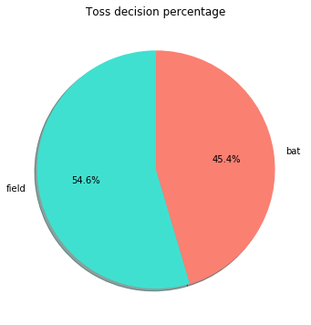

```python
#get the toss outcomes
temp_series = matches.toss_decision.value_counts()

#visualize the outcomes
labels = (np.array(temp_series.index))
sizes = (np.array((temp_series / temp_series.sum())*100))
colors = ['turquoise', 'salmon']
plt.figure(figsize=(6,6))
plt.pie(sizes, labels=labels, colors=colors,
        autopct='%1.1f%%', shadow=True, startangle=90)
plt.title("Toss decision percentage")
plt.show()
```

#### Trend 1

We can see that it is preferred to field than to bat after winning the toss but the difference is not significant.

Let's see how if this decision varied over the years.

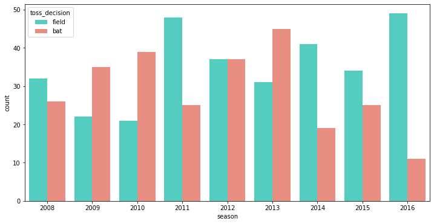

```python
plt.figure(figsize=(12,6))
sns.countplot(x='season',hue='toss_decision',data=matches, palette=['turquoise', 'salmon'])
plt.show()
```

#### Trend 2

We can see that there is a clear trend here. In the initial years, the teams preferred to bat first equally likely as to field first but over the years there's a clear trend of choosing to field first.

#### Now let's see how this decision affected winning of the matches

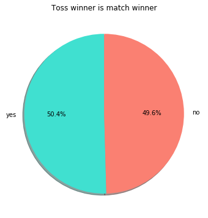

```python
matches['toss_winner_is_winner'] = 'no'
matches['toss_winner_is_winner'][matches.toss_winner == matches.winner] = 'yes'
temp_series = matches.toss_winner_is_winner.value_counts(normalize=True)

labels = (np.array(temp_series.index))
sizes = (np.array(temp_series*100))
colors = ['turquoise', 'salmon']
plt.figure(figsize=(6,6))
plt.pie(sizes, labels=labels, colors=colors,
        autopct='%1.1f%%', shadow=True, startangle=90)
plt.title("Toss winner is match winner")
plt.show()
```

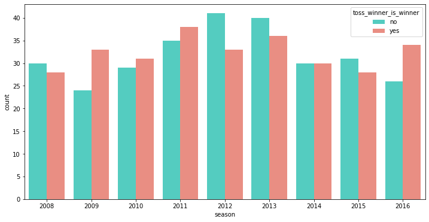

```python
#check the above trend over the years
plt.figure(figsize=(12,6))
sns.countplot(x='season',hue='toss_winner_is_winner',data=matches, palette=['turquoise', 'salmon'])
plt.show()
```

### Outcome of Hypothesis 1

As seen above it's very clear that there is no correlation between winning the toss and winning the match over the years.

## Hypothesis 2

Impact of winning the toss, electing to bat and scoring 100 runs in the first 10 overs on the eventual match outcome.

```python
#join the matches and deliveries dataset
data = pd.merge(left=matches, right=deliveries, how='inner', left_on='id', right_on='match_id')
data.head(5)
```

|  | id | season | city | date | team1 | team2 | toss_winner | toss_decision | result | dl_applied | winner | win_by_runs | win_by_wickets | player_of_match | venue | umpire1 | umpire2 | umpire3 | toss_winner_is_winner | match_id | inning | batting_team | bowling_team | over | ball | batsman | non_striker | bowler | is_super_over | … |
| --- | --- | --- | --- | --- | --- | --- | --- | --- | --- | --- | --- | --- | --- | --- | --- | --- | --- | --- | --- | --- | --- | --- | --- | --- | --- | --- | --- | --- | --- | --- |
| 0 | 1 | 2008 | Bangalore | 2008-04-18 | KKR | RCB | RCB | field | normal | 0 | KKR | 140 | 0 | BB McCullum | M Chinnaswamy Stadium | Asad Rauf | RE Koertzen | NaN | no | 1 | 1 | KKR | RCB | 1 | 1 | SC Ganguly | BB McCullum | P Kumar | 0 | … |
| 1 | 1 | 2008 | Bangalore | 2008-04-18 | KKR | RCB | RCB | field | normal | 0 | KKR | 140 | 0 | BB McCullum | M Chinnaswamy Stadium | Asad Rauf | RE Koertzen | NaN | no | 1 | 1 | KKR | RCB | 1 | 2 | BB McCullum | SC Ganguly | P Kumar | 0 | … |
| 2 | 1 | 2008 | Bangalore | 2008-04-18 | KKR | RCB | RCB | field | normal | 0 | KKR | 140 | 0 | BB McCullum | M Chinnaswamy Stadium | Asad Rauf | RE Koertzen | NaN | no | 1 | 1 | KKR | RCB | 1 | 3 | BB McCullum | SC Ganguly | P Kumar | 0 | … |
| 3 | 1 | 2008 | Bangalore | 2008-04-18 | KKR | RCB | RCB | field | normal | 0 | KKR | 140 | 0 | BB McCullum | M Chinnaswamy Stadium | Asad Rauf | RE Koertzen | NaN | no | 1 | 1 | KKR | RCB | 1 | 4 | BB McCullum | SC Ganguly | P Kumar | 0 | … |
| 4 | 1 | 2008 | Bangalore | 2008-04-18 | KKR | RCB | RCB | field | normal | 0 | KKR | 140 | 0 | BB McCullum | M Chinnaswamy Stadium | Asad Rauf | RE Koertzen | NaN | no | 1 | 1 | KKR | RCB | 1 | 5 | BB McCullum | SC Ganguly | P Kumar | 0 | … |

```python
#define a function to roll up the data for first 10 overs

def match_rollup(match):
    bat_first_runs_10overs = None
    field_first_wickets_10overs = None
    if match['toss_decision'][0] == 'bat':
        bat_first_runs_10overs = match[(match['inning'] == 1) & (match['over'] <= 10)]['total_runs'].sum()
    elif match['toss_decision'][0] == 'field':
        field_first_wickets_10overs = match[(match['inning'] == 1) & (match['over'] <= 10)]['player_dismissed'].notna().sum()

    return pd.Series([bat_first_runs_10overs, field_first_wickets_10overs],
                     index=['bat_first_runs_10overs', 'field_first_wickets_10overs'])
```

```python
#apply above function on each ID
data_rolled_up = data.groupby('id').apply(match_rollup).reset_index()
matches2 = pd.merge(left=matches, right=data_rolled_up, how='inner', on='id')
matches2.head()
```

|  | id | season | city | date | team1 | team2 | toss_winner | toss_decision | result | dl_applied | winner | win_by_runs | win_by_wickets | player_of_match | venue | umpire1 | umpire2 | umpire3 | toss_winner_is_winner | bat_first_runs_10overs | field_first_wickets_10overs |
| --- | --- | --- | --- | --- | --- | --- | --- | --- | --- | --- | --- | --- | --- | --- | --- | --- | --- | --- | --- | --- | --- |
| 0 | 1 | 2008 | Bangalore | 2008-04-18 | KKR | RCB | RCB | field | normal | 0 | KKR | 140 | 0 | BB McCullum | M Chinnaswamy Stadium | Asad Rauf | RE Koertzen | NaN | no | NaN | 1.0 |
| 1 | 2 | 2008 | Chandigarh | 2008-04-19 | CSK | KXIP | CSK | bat | normal | 0 | CSK | 33 | 0 | MEK Hussey | Punjab Cricket Association Stadium, Mohali | MR Benson | SL Shastri | NaN | yes | 88.0 | NaN |
| 2 | 3 | 2008 | Delhi | 2008-04-19 | RR | DD | RR | bat | normal | 0 | DD | 0 | 9 | MF Maharoof | Feroz Shah Kotla | Aleem Dar | GA Pratapkumar | NaN | no | 57.0 | NaN |
| 3 | 4 | 2008 | Mumbai | 2008-04-20 | MI | RCB | MI | bat | normal | 0 | RCB | 0 | 5 | MV Boucher | Wankhede Stadium | SJ Davis | DJ Harper | NaN | no | 74.0 | NaN |
| 4 | 5 | 2008 | Kolkata | 2008-04-20 | DC | KKR | DC | bat | normal | 0 | KKR | 0 | 5 | DJ Hussey | Eden Gardens | BF Bowden | K Hariharan | NaN | no | 52.0 | NaN |

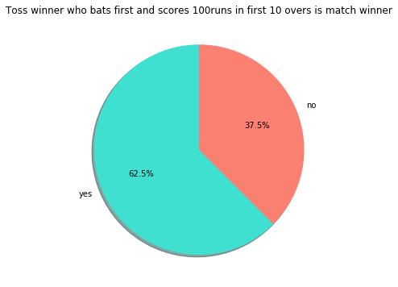

```python
#filter the required data as per hypothesis
matches_wt_bf_100runs = matches2[matches2['bat_first_runs_10overs'].notna() & (matches2['bat_first_runs_10overs'] > 100)].copy()

matches_wt_bf_100runs['conditional_winner'] = 'no'
matches_wt_bf_100runs['conditional_winner'][matches_wt_bf_100runs.toss_winner == matches_wt_bf_100runs.winner] = 'yes'


#plot the above hypothesis
temp_series = matches_wt_bf_100runs.conditional_winner.value_counts(normalize=True)

labels = (np.array(temp_series.index))
sizes = (np.array(temp_series*100))
colors = ['turquoise', 'salmon']
plt.figure(figsize=(6,6))
plt.pie(sizes, labels=labels, colors=colors,
        autopct='%1.1f%%', shadow=True, startangle=90)
plt.title("Toss winner who bats first and scores 100runs in first 10 overs is match winner")
plt.show()
```

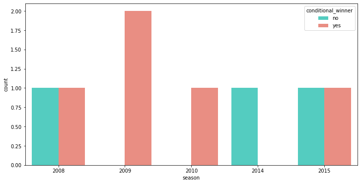

```python
#plot the hypothesis over the years
plt.figure(figsize=(12,6))
sns.countplot(x='season',hue='conditional_winner',data=matches_wt_bf_100runs, palette=['turquoise', 'salmon'])
plt.show()
```

### Outcome of Hypothesis 2

As seen above there is an advantage to scoring 100 runs in the first 10 overs on the eventual win probability in a game.

## Hypothesis 3

Let's check if winning the toss, electing to field and taking 3 wickets in first 10 overs makes a big enough difference

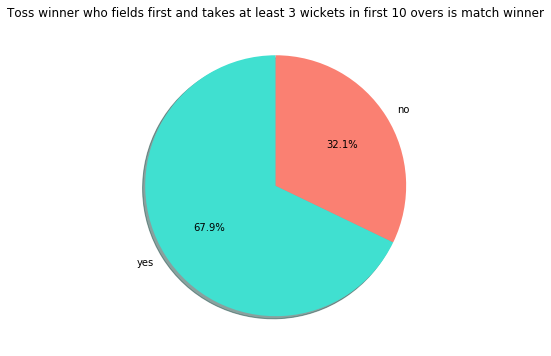

```python
#filter for the above hypothesis
matches_wt_ff_3wick = matches2[matches2['field_first_wickets_10overs'].notna() & (matches2['field_first_wickets_10overs'] >= 3)].copy()

matches_wt_ff_3wick['conditional_winner'] = 'no'
matches_wt_ff_3wick['conditional_winner'][matches_wt_ff_3wick.toss_winner == matches_wt_ff_3wick.winner] = 'yes'

#plot the hypothesis
temp_series = matches_wt_ff_3wick.conditional_winner.value_counts(normalize=True)

labels = (np.array(temp_series.index))
sizes = (np.array(temp_series*100))
colors = ['turquoise', 'salmon']
plt.figure(figsize=(6,6))
plt.pie(sizes, labels=labels, colors=colors,
        autopct='%1.1f%%', shadow=True, startangle=90)
plt.title("Toss winner who fields first and takes at least 3 wickets in first 10 overs is match winner")
plt.show()
```

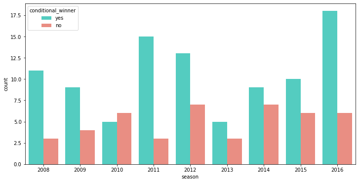

```python
#check the hypothesis across the seasons
plt.figure(figsize=(12,6))
sns.countplot(x='season',hue='conditional_winner',data=matches_wt_ff_3wick, palette=['turquoise', 'salmon'])
plt.show()
```

### Outcome of Hypothesis 3

As seen above there is an significant advantage in taking 3 wickets in the first 10 overs on the eventual win probabilty in a game.

## Hypothesis 4:

Does the opening paternship play a significant role in the end result of the game?

```
[Text(0, 0.5, 'No. of Runs'), Text(0.5, 0, 'Scenerio')]
```

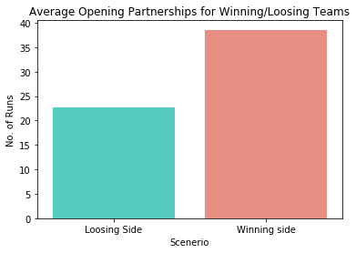

```python
matches = matches.loc[matches.winner.notna()] #dont include tied games
matches["team1 won"] = matches["team1"] == matches["winner"]

#Matches where team1 bats first - team1 always bats first! Team2 bats second.
#df_matches.loc[(df_matches["team1 toss won"] & (df_matches["toss_decision"] == "bat") ) | (~df_matches["team1 toss won"] & (df_matches["toss_decision"] != "bat") )]

#winners ka
winners_df = pd.DataFrame(matches.loc[matches["team1 won"],"id"].unique(),columns=["match_id"]) #select 1 innings
winners_df["bat_innings"] = 1

winners_df_2 = pd.DataFrame(matches.loc[~matches["team1 won"],"id"].unique(),columns=["match_id"])
winners_df_2["bat_innings"] = 2

winners_df = pd.concat([winners_df,winners_df_2],ignore_index=True)

def fun2(grouped):
    rows = grouped[pd.notna(grouped["player_dismissed"])].index.min() - grouped.index[0]
    if pd.isna(rows):
        return grouped.shape[0]
    return rows

#tells number of records for the opening partnership for each innings and match
all_df = deliveries[["match_id","inning","player_dismissed","ball","total_runs"]].groupby(["match_id","inning"],sort=False,as_index=False).apply(fun2).reset_index()

def fun3(grouped):
    count= int(grouped.head(1)["count"])
    return sum(grouped["total_runs"].iloc[:count])

def opening_partnership_return(try__):
    try__ = pd.merge(deliveries[["match_id","inning","total_runs"]],try__,on=["match_id","inning"])
    try__ = try__.reset_index(drop=True)
    try__ = try__.rename({0:"count"},axis=1)
    return np.mean(try__.groupby(["match_id","inning"],as_index=False).apply(fun3)) #overall average

loosers_df = winners_df.copy()
loosers_df["bat_innings"] = -1.5*(loosers_df["bat_innings"]**2) +(3.5*loosers_df["bat_innings"]) #swaps 1 and 2
loosers_df["bat_innings"] = loosers_df["bat_innings"].astype(np.uint8)

winners_df = pd.merge(all_df,winners_df,left_on=["match_id","inning"],right_on=["match_id","bat_innings"]).drop("bat_innings",axis=1)
loosers_df = pd.merge(all_df,loosers_df,left_on=["match_id","inning"],right_on=["match_id","bat_innings"]).drop("bat_innings",axis=1)
res = [opening_partnership_return(loosers_df),opening_partnership_return(winners_df),opening_partnership_return(all_df)][:2]
x_ax = ["Loosing Side","Winning side"]

ax=sns.barplot(x_ax,res,palette=['turquoise', 'salmon'])
ax.set_title('Average Opening Partnerships for Winning/Loosing Teams')
ax.set(xlabel='Scenerio', ylabel='No. of Runs')
```

### Outcome of Hypothesis 4

As seen above there is a significant importance of having a good opening partnership in the eventaul result of the match.

## Hypothesis Summary

The teams need to focus on sending their best batsmen, not necessarily their designated opening batsmen or bowlers to have the best chances of winning the game and the toss does not have any affect on the outcome of the game

# Statistical Modeling for obtaining best performing players

### Develop a scoring system for each of the categories of the game: Batting, Bowling and Fielding and then find the most valuable players across the IPL over the years

```python
s_man_of_match = (matches.groupby(matches.player_of_match).player_of_match.count().
                  sort_values(ascending=False).head(15))

df_man_of_match =(s_man_of_match.to_frame().rename
                  (columns = {"player_of_match": "times"}).reset_index())

cen = deliveries.groupby(['batsman','match_id']).agg({'batsman_runs':'sum'})
cen = cen[cen['batsman_runs']>=100]
cen = cen.groupby(['batsman']).agg({'count'})
cen.columns = cen.columns.droplevel()
cen = cen.sort_values(by='count',ascending=False).reset_index()

half_cen = deliveries.groupby(['batsman','match_id']).agg({'batsman_runs':'sum'})
half_cen = half_cen[half_cen['batsman_runs']>=50]
half_cen = half_cen[half_cen['batsman_runs']<100]
half_cen = half_cen.groupby(['batsman']).agg({'count'})
half_cen.columns = half_cen.columns.droplevel()
half_cen = half_cen.sort_values(by='count',ascending=False).reset_index()

df_big = pd.merge(cen,half_cen, on='batsman',how='right')
df_big = df_big.fillna(0)

df_strike_rate = deliveries.groupby(['batsman']).agg({'ball':'count','batsman_runs':'mean'}).sort_values(by='batsman_runs',ascending=False)
df_strike_rate.rename(columns ={'batsman_runs' : 'strike rate'}, inplace=True)

df_runs_per_match = deliveries.groupby(['batsman','match_id']).agg({'batsman_runs':'sum'})
df_total_runs = df_runs_per_match.groupby(['batsman']).agg({'sum' ,'mean','count'})
df_total_runs.rename(columns ={'sum' : 'batsman run','count' : 'match count','mean' :'average score'}, inplace=True)
df_total_runs.columns = df_total_runs.columns.droplevel()

df_sixes = deliveries[['batsman','batsman_runs']][deliveries.batsman_runs==6].groupby(['batsman']).agg({'batsman_runs':'count'})
df_four = deliveries[['batsman','batsman_runs']][deliveries.batsman_runs==4].groupby(['batsman']).agg({'batsman_runs':'count'})

df_batsman_stat = pd.merge(pd.merge(pd.merge(df_strike_rate,df_total_runs, left_index=True, right_index=True),
                                    df_sixes, left_index=True, right_index=True),df_four, left_index=True, right_index=True)

df_batsman_stat.rename(columns = {'ball' : 'Ball', 'strike rate':'Strike Rate','batsman run' : 'Batsman Run','match count' : 'Match Count',
                                  'average score' : 'Average score' ,'batsman_runs_x' :'Six','batsman_runs_y':'Four'},inplace=True)
df_batsman_stat['Strike Rate'] = df_batsman_stat['Strike Rate']*100
df_batsman_stat = df_batsman_stat.sort_values(by='Batsman Run',ascending=False).reset_index()

batsman_stats = pd.merge(df_batsman_stat,df_big, on='batsman',how='left').fillna(0)
batsman_stats.rename(columns = {'count_x' : '100s', 'count_y' : '50s'},inplace=True)
```

```python
condition_catch = (deliveries.dismissal_kind == 'caught')
condition_run= (deliveries.dismissal_kind == 'run out')
condition_stump= (deliveries.dismissal_kind == 'stumped')
condition_caught_bowled = (deliveries.dismissal_kind == 'caught and bowled')

s_catch = deliveries.loc[condition_catch,:].groupby(deliveries.fielder).dismissal_kind.count().sort_values(ascending=False)
s_run = deliveries.loc[condition_run,:].groupby(deliveries.fielder).dismissal_kind.count().sort_values(ascending=False)
s_stump = deliveries.loc[condition_stump,:].groupby(deliveries.fielder).dismissal_kind.count().sort_values(ascending=False)
s_caught_bowled = deliveries.loc[condition_caught_bowled,:].groupby(deliveries.bowler).dismissal_kind.count().sort_values(ascending=False)

df_catch= s_catch.to_frame().reset_index().rename(columns ={'dismissal_kind' : 'catch'})
df_run= s_run.to_frame().reset_index().rename(columns ={'dismissal_kind' : 'run_out'})
df_stump= s_stump.to_frame().reset_index().rename(columns ={'dismissal_kind' : 'stump'})
df_caught_bowled = s_caught_bowled.to_frame().reset_index().rename(columns ={'dismissal_kind' : 'caught and bowled'})

df_field = pd.merge(pd.merge(df_catch,df_run,on='fielder', how='outer'),df_stump,on='fielder',how='outer')
field_stats = df_field[~df_field['fielder'].str.contains("(sub)")].reset_index().drop(['index'],axis=1).fillna(0)
```

```python
condition = ((deliveries.dismissal_kind.notnull()) &(deliveries.dismissal_kind != 'run out')&
            (deliveries.dismissal_kind != 'retired hurt' )&(deliveries.dismissal_kind != 'hit wicket')
            &(deliveries.dismissal_kind != 'obstructing the field')&(deliveries.dismissal_kind != 'caught and bowled'))

df_bowlers = deliveries.loc[condition,:].groupby(deliveries.bowler).dismissal_kind.count().sort_values(ascending=False).reset_index()
df_bowlers = pd.merge(df_bowlers,df_caught_bowled , on='bowler',how='left').fillna(0)

high=deliveries.groupby(['match_id', 'bowler']).agg({'total_runs':'sum'}).reset_index()

over_count=deliveries.groupby(['match_id', 'bowler','over']).agg({'total_runs':'sum'}).reset_index()
overs = over_count.groupby(['match_id','bowler']).agg({'over':'count'}).reset_index()
overs = overs[overs['over']>=2]

bowlers = pd.merge(high,overs,on=['match_id', 'bowler'], how='right')
bowlers['economy'] = bowlers['total_runs']/bowlers['over']
bowlers['eco_range'] = pd.cut(bowlers['economy'], [0, 4, 5, 6, 9, 10, 11, 30], labels=['below4', '4-5', '5-6', '6-9','9-10','10-11','above11'])

bowlers = pd.concat([bowlers,pd.get_dummies(bowlers['eco_range'], prefix='eco')],axis=1)
economy_rates=bowlers.groupby(['bowler']).agg({'eco_below4':'sum','eco_4-5':'sum','eco_5-6':'sum','eco_6-9':'sum','eco_9-10':'sum','eco_10-11':'sum','eco_above11':'sum'}).reset_index()

maiden_over = over_count[over_count['total_runs']==0]
maidens = maiden_over['bowler'].value_counts().to_frame().reset_index().rename({'index':'bowler','bowler':'maiden_overs'},axis=1)

hauls=deliveries.groupby(['match_id', 'bowler']).agg({'player_dismissed':'count'}).reset_index()
hauls = hauls[hauls['player_dismissed']>=4]
hauls['haul'] = pd.cut(hauls['player_dismissed'], [0,4,8], labels=['4', '5'])
hauls = pd.concat([hauls,pd.get_dummies(hauls['haul'], prefix='haul')],axis=1)
hauls.drop(['player_dismissed','haul'],inplace=True,axis=1)
hauls=hauls.groupby(['bowler']).agg({'haul_4':'sum','haul_5':'sum'}).reset_index()

bowlers_stats = pd.merge(pd.merge(pd.merge(economy_rates,maidens,on='bowler', how='left'),df_bowlers,on='bowler',how='left'),hauls,on='bowler',how='right').fillna(0)
bowlers_stats.rename(columns ={'dismissal_kind' : 'wickets'},inplace=True)
```

### Century and Half Century Analysis

```python
centuries = batsman_stats.sort_values(by='100s').tail(15)
half_centuries = batsman_stats.sort_values(by='50s').tail(15)

fig = {"data" : [{"x" : centuries["batsman"],"y" : centuries["100s"],
                  "name" : "100s","marker" : {"color" : "lightblue","size": 12},
                  "line": {"width" : 3},"type" : "scatter","mode" : "lines+markers" ,
                  "xaxis" : "x1","yaxis" : "y1"},

                 {"x" : half_centuries["batsman"],"y" : half_centuries["50s"],
                  "name" : "50s","marker" : {"color" : "brown","size": 12},
                  "type" : "scatter","line": {"width" : 3},"mode" : "lines+markers",
                  "xaxis" : "x2","yaxis" : "y2"}],

        "layout" : {"title": "Total centuries and half-centuries by top batsman",
                    "xaxis2" : {"domain" : [0, 1],"anchor" : "y2",
                    "showticklabels" : True},"margin" : {"b" : 111},
                    "yaxis2" : {"domain" : [.55, 1],"anchor" : "x2","title": "50s"},
                    "xaxis" : {"domain" : [0, 1],"tickmode":'linear',"title": "Batsman"},
                    "yaxis" : {"domain" :[0, .45], "anchor" : "x2","title": "100s"}}}

iplot(fig)
```

[interactive chart not shown]

```python
cen = batsman_stats[['100s','50s','batsman']]
cen['points'] = (cen['100s']*8) + (cen['50s']*4)
cen.sort_values(by='points',inplace=True,ascending=False)

trace = go.Table(
    domain=dict(x=[0, 0.55],
                y=[0, 1.0]),
    header=dict(values=["Batsman","Points","100s","50s"],
                fill = dict(color = '#119DFF'),
                font = dict(color = 'white', size = 14),
                align = ['center'],
               height = 30),
    cells=dict(values=[cen['batsman'].head(10), cen['points'].head(10), cen['100s'].head(10), cen['50s'].head(10)],
               fill = dict(color = ['#25FEFD', 'white']),
               align = ['center']))

trace1 = go.Bar(x=cen['batsman'].head(10),
                y=cen["points"].head(10),
                xaxis='x1',
                yaxis='y1',
                marker=dict(color='brown'),opacity=0.60)

layout = dict(
    width=830,
    height=415,
    autosize=False,
    title='Batsman with highest points by centuries and half centuries',
    margin = dict(t=100),
    showlegend=False,
    xaxis1=dict(**dict(domain=[0.65, 1], anchor='y1', showticklabels=True)),
    yaxis1=dict(**dict(domain=[0, 1.0], anchor='x1', hoverformat='.2f')),
)

fig1 = dict(data=[trace, trace1], layout=layout)
iplot(fig1)
```

[interactive chart not shown]

### Boundaries and total runs analysis

```python
fours = batsman_stats.sort_values(by='Four').tail(15)
sixes = batsman_stats.sort_values(by='Six').tail(15)
runs = batsman_stats.sort_values(by='Batsman Run').tail(15)

trace1 = go.Scatter(x=sixes.batsman,y =sixes.Six,name='6"s',marker =dict(color= "blue",size = 9),line=dict(width=2,dash='dash'),showlegend=True)
trace2 = go.Scatter(x=fours.batsman,y = fours.Four,name='4"s',marker =dict(color= "green",size = 9),line=dict(width=2,dash='longdash'))
trace3 = go.Scatter(x=runs.batsman,y = runs['Batsman Run'],name='2"s',marker =dict(color= "red",size = 9),line=dict(width=2,dash='dashdot'))

fig = tools.make_subplots(rows=3, cols=1, subplot_titles=('Top 6"s Scorer','Top 4"s Scorer',"Highest total runs"), print_grid=False)

fig.append_trace(trace1, 1, 1)
fig.append_trace(trace2, 2, 1)
fig.append_trace(trace3, 3, 1)

fig['layout'].update(height=700, width=820,title='Top Scorer in Boundaries and Total Runs',showlegend=False)
iplot(fig)
```

[interactive chart not shown]

```python
runs = batsman_stats[['Six','Four','Batsman Run','batsman']]
runs['point'] = (runs['Six']*1) + (runs['Four']*0.5) + (runs['Batsman Run']*0.5)
runs.sort_values(by='point',inplace=True,ascending=False)

final = pd.merge(cen,runs,on='batsman', how='inner')
final['total_points']=final['points']+final['point']
final['max'] = final['100s']+final['50s']

final.sort_values(by='total_points',ascending=False,inplace=True)
best_batsman = final[['batsman','total_points']]
```

```python
trace = go.Table(
    domain=dict(x=[0, 0.55],
                y=[0, 1.0]),
    header=dict(values=["Batsman","Points","Sixes","Fours"],
                fill = dict(color='#d562be'),
                font = dict(color=['rgb(45, 45, 45)'] * 5, size=14),
                align = ['center'],
               height = 30),
    cells=dict(values=[runs['batsman'].head(10), runs['point'].head(10), runs['Six'].head(10), runs['Four'].head(10)],
               fill = dict(color=['rgb(235, 193, 238)', 'rgba(228, 222, 249, 0.65)']),
               align = ['center']))

trace1 = go.Bar(x=runs['batsman'].head(10),
                y=runs["point"].head(10),
                xaxis='x1',
                yaxis='y1',
                marker=dict(color='gold'),opacity=0.60)

layout = dict(
    width=830,
    height=415,
    autosize=False,
    title='Batsman with highest points by runs and boundaries',
    margin = dict(t=100),
    showlegend=False,
    xaxis1=dict(**dict(domain=[0.61, 1], anchor='y1', showticklabels=True)),
    yaxis1=dict(**dict(domain=[0, 1.0], anchor='x1', hoverformat='.2f')),
)

fig1 = dict(data=[trace, trace1], layout=layout)
iplot(fig1)
```

[interactive chart not shown]

## Fielder Analysis

### Fielder with maximum catches

```python
trace1 = go.Bar(x=field_stats.fielder.head(15),y=field_stats.catch,
                name='Caught',opacity=0.4)

trace2 = go.Bar(x=field_stats.fielder.head(15),y=field_stats.run_out,name='Run out',
                marker=dict(color='red'),opacity=0.4)

trace3 = go.Bar(x=field_stats.fielder.head(15),y=field_stats.stump,name='Stump out',
                marker=dict(color='lime'),opacity=0.4)

data = [trace1, trace2, trace3]
layout = go.Layout(title='Best fielders',
                   xaxis=dict(title='Player',tickmode='linear'),
                   yaxis=dict(title='Dismissals'),bargap=0.2,bargroupgap=0.1)

fig = go.Figure(data=data, layout=layout)
iplot(fig)
```

[interactive chart not shown]

### Fielder with maximum points

```python
field = field_stats[['fielder','stump','catch','run_out']]


field1 = field[(field['stump'] > 0)]
field2 = field[~(field['stump'] > 0)]

field1['points'] = (field1['catch']*4) + (field1['stump']*6) + (field1['run_out']*2)
field2['points'] = (field2['catch']*4) + (field2['stump']*6) + (field2['run_out']*6)

field = pd.concat([field1, field2])
field.sort_values(by='points',ascending=False,inplace=True)

field1.sort_values(by='points',ascending=False,inplace=True)
field2.sort_values(by='points',ascending=False,inplace=True)

best_fielder = field[['fielder','points']]
```

```python
trace = go.Table(
    domain=dict(x=[0, 0.65],
                y=[0, 1.0]),
    header=dict(values=["Fielder","Stump","Catch","Run out","Points"],
                fill = dict(color = 'grey'),
                font = dict(color = 'white', size = 14),
                align = ['center'],
               height = 30),
    cells=dict(values=[field['fielder'].head(10),field['stump'].head(10),field['catch'].head(10),field['run_out'].head(10),field['points'].head(10)],
               fill = dict(color = ['lightgrey', 'white']),
               align = ['center']))

trace1 = go.Bar(x=field['fielder'].head(10),
                y=field["points"].head(10),
                xaxis='x1',
                yaxis='y1',
                marker=dict(color='hotpink'),opacity=0.60)

layout = dict(
    width=850,
    height=440,
    autosize=False,
    title='Fielder with maximum Points',
    showlegend=False,
    xaxis1=dict(**dict(domain=[0.7, 1], anchor='y1', showticklabels=True)),
    yaxis1=dict(**dict(domain=[0, 1.0], anchor='x1', hoverformat='.2f')),
)

fig1 = dict(data=[trace, trace1], layout=layout)
iplot(fig1)
```

[interactive chart not shown]

### Fielders and Wicketkeepers with maximum points

```python
trace0 = go.Scatter(
    x=field1['points'].head(5),
    y=field1['fielder'],
    name = 'Wicketkeeper',
    mode='markers',
    marker=dict(
        color='rgba(156, 165, 196, 0.95)',
        line=dict(color='rgba(156, 165, 196, 1.0)',width=1),
        symbol='circle',
        size=16,
    ))
trace1 = go.Scatter(
    x=field2['points'].head(5),
    y=field2['fielder'],
    name='Fielder',
    mode='markers',
    marker=dict(
        color='rgba(204, 204, 204, 0.95)',
        line=dict(color='rgba(217, 217, 217, 1.0)',width=1),
        symbol='circle',
        size=16,
    ))

data = [trace0,trace1]
layout = go.Layout(
    title="Ten best Fielders and Wicketkeepers for IPL",
    xaxis=dict(
        showgrid=False,
        showline=True,
        linecolor='rgb(102, 102, 102)',
        titlefont=dict(color='rgb(204, 204, 204)'),
        tickfont=dict(color='rgb(102, 102, 102)',),
        showticklabels=True,
        ticks='outside',
        tickcolor='rgb(102, 102, 102)',
    ),
    margin=dict(l=140,r=40,b=50,t=80),
    legend=dict(
        font=dict(size=10,),
        yanchor='middle',
        xanchor='right',
    ),
    hovermode='closest',
)
fig = go.Figure(data=data, layout=layout)
iplot(fig)
```

[interactive chart not shown]

## Bowler Analysis

### Wicket Haul Analysis

```python
haul5 = bowlers_stats.sort_values(by='haul_5',ascending=False).head(10)
haul4 = bowlers_stats.sort_values(by='haul_4',ascending=False).head(10)

trace1 = go.Scatter(x=haul5['bowler'],y=haul5['haul_5'],name='5 Wickets Haul',marker =dict(color= "gold",size = 13),line=dict(width=3,dash='longdashdot'))
trace2 = go.Scatter(x=haul4['bowler'],y=haul4['haul_4'],name='4 Wickets Haul',marker =dict(color= "lightgrey",size = 13),line=dict(width=3))

fig = tools.make_subplots(rows=1, cols=2, subplot_titles=('Five Wickets','Four Wickets'), print_grid=False)

fig.append_trace(trace1, 1, 1)
fig.append_trace(trace2, 1, 2)

iplot(fig)
```

[interactive chart not shown]

### Bowlers with maximum dismissals analysis

```python
wicket = bowlers_stats.sort_values(by='wickets',ascending=False).head(10)
caught_bowled = bowlers_stats.sort_values(by='caught and bowled',ascending=False).head(10)

dismissals = bowlers_stats[['bowler','wickets','caught and bowled']]
dismissals['dismissals'] = dismissals['wickets']+dismissals['caught and bowled']

dismissals['points'] = (dismissals['wickets']*10) + (dismissals['caught and bowled']*14)
dismissals.sort_values(by='points',ascending=False,inplace=True)
```

```python
trace = go.Table(
    domain=dict(x=[0, 0.52],
                y=[0, 1.0]),
    header=dict(values=["Bowler","Dismissals","Points"],
                fill = dict(color = 'red'),
                font = dict(color = 'white', size = 14),
                align = ['center'],
               height = 30),
    cells=dict(values=[dismissals['bowler'].head(10),dismissals['dismissals'].head(10),dismissals['points'].head(10)],
               fill = dict(color = ['lightsalmon', 'white']),
               align = ['center']))

trace1 = go.Bar(x=dismissals['bowler'].head(10),
                y=dismissals["points"].head(10),
                xaxis='x1',
                yaxis='y1',
                marker=dict(color='lightblue'),opacity=0.60)

layout = dict(
    width=830,
    height=410,
    autosize=False,
    title='Bowlers with maximum dismissal points',
    showlegend=False,
    xaxis1=dict(**dict(domain=[0.58, 1], anchor='y1', showticklabels=True)),
    yaxis1=dict(**dict(domain=[0, 1.0], anchor='x1', hoverformat='.2f')),
)

fig1 = dict(data=[trace, trace1], layout=layout)
iplot(fig1)
```

[interactive chart not shown]

### Best bowlers in each economy range

```python
e1 = bowlers_stats.sort_values(by='eco_below4',ascending=False).head(10)
e2 = bowlers_stats.sort_values(by='eco_4-5',ascending=False).head(10)
e3 = bowlers_stats.sort_values(by='eco_5-6',ascending=False).head(10)
e4 = bowlers_stats.sort_values(by='eco_6-9',ascending=False).head(10)
e5 = bowlers_stats.sort_values(by='eco_9-10',ascending=False).head(10)
e6 = bowlers_stats.sort_values(by='eco_10-11',ascending=False).head(10)
e7 = bowlers_stats.sort_values(by='eco_above11',ascending=False).head(10)
m = bowlers_stats.sort_values(by='maiden_overs',ascending=False).head(10)
```

```python
trace1 = go.Scatter(x=e1['bowler'],y = e1['eco_below4'],name='below 4')
trace2 = go.Scatter(x=e2['bowler'],y = e2['eco_4-5'],name='between 4-5')
trace3 = go.Scatter(x=e3['bowler'],y = e3['eco_5-6'],name='between 5-6')
trace4 = go.Scatter(x=e4['bowler'],y = e4['eco_6-9'],name='between 6-9')
trace5 = go.Scatter(x=e5['bowler'],y = e5['eco_9-10'],name='between 9-10')
trace6 = go.Scatter(x=e6['bowler'],y = e6['eco_10-11'],name='between 10-11')
trace7 = go.Scatter(x=e7['bowler'],y = e7['eco_above11'],name='above 11')
trace8 = go.Scatter(x=m['bowler'],y = m['maiden_overs'],name='Maiden overs')

fig = tools.make_subplots(rows=4, cols=2,print_grid=False,
                          subplot_titles=('Economy below 4','Economy between 4-5','Economy between 5-6',
                                          'Economy between 6-9','Economy between 9-10','Economy between 10-11',
                                          'Economy above 11','Maiden Overs'))

fig.append_trace(trace1, 1, 1)
fig.append_trace(trace2, 1, 2)
fig.append_trace(trace3, 2, 1)
fig.append_trace(trace4, 2, 2)
fig.append_trace(trace5, 3, 1)
fig.append_trace(trace6, 3, 2)
fig.append_trace(trace7, 4, 1)
fig.append_trace(trace8, 4, 2)


fig['layout'].update(height=950, width=850,title='Economy and maiden Overs analysis',showlegend=False)
iplot(fig)
```

[interactive chart not shown]

### Bowlers with maximum economy and maiden points

```python
eco = bowlers_stats[['bowler','maiden_overs','eco_below4','eco_4-5','eco_5-6','eco_9-10','eco_10-11','eco_above11']]

eco['points'] = ((eco['eco_below4']*3)+(eco['eco_4-5']*2)+(eco['eco_5-6']*1)+
                 (eco['eco_9-10']*(-1))+(eco['eco_10-11']*(-2))+(eco['eco_above11']*(-3))+(eco['maiden_overs']*4))

eco.sort_values(by='points',ascending=False,inplace=True)

eco.head()
```

|  | bowler | maiden_overs | eco_below4 | eco_4-5 | eco_5-6 | eco_9-10 | eco_10-11 | eco_above11 | points |
| --- | --- | --- | --- | --- | --- | --- | --- | --- | --- |
| 76 | SL Malinga | 8.0 | 10 | 10 | 17 | 6 | 7 | 1 | 76.0 |
| 64 | R Ashwin | 5.0 | 12 | 16 | 18 | 4 | 10 | 3 | 73.0 |
| 78 | SP Narine | 3.0 | 9 | 8 | 17 | 5 | 0 | 2 | 61.0 |
| 29 | Harbhajan Singh | 3.0 | 8 | 12 | 18 | 10 | 6 | 5 | 41.0 |
| 1 | A Kumble | 3.0 | 5 | 9 | 5 | 5 | 0 | 2 | 39.0 |

```python
trace = go.Table(
    domain=dict(x=[0, 0.52],
                y=[0, 1.0]),
    header=dict(values=["Bowler","Maiden Overs","Points"],
                fill = dict(color = 'green'),
                font = dict(color = 'white', size = 14),
                align = ['center'],
               height = 30),
    cells=dict(values=[eco['bowler'].head(10),eco['maiden_overs'].head(10),eco['points'].head(10)],
               fill = dict(color = ['lightgreen', 'white']),
               align = ['center']))

trace1 = go.Bar(x=eco['bowler'].head(10),
                y=eco["points"].head(10),
                xaxis='x1',
                yaxis='y1',
                marker=dict(color='gray'),opacity=0.60,name='bowler')

layout = dict(
    width=830,
    height=410,
    autosize=False,
    title='Bowlers with maximum economy and maiden points',
    showlegend=False,
    xaxis1=dict(**dict(domain=[0.56, 1], anchor='y1', showticklabels=True)),
    yaxis1=dict(**dict(domain=[0, 1.0], anchor='x1', hoverformat='.2f')),
)

fig1 = dict(data=[trace, trace1], layout=layout)
iplot(fig1)
```

[interactive chart not shown]

### Bowlers with maximum points analysis

```python
final = bowlers_stats
final['points_x'] = ((final['eco_below4']*3)+(final['eco_4-5']*2)+(final['eco_5-6']*1)+(final['eco_9-10']*(-1))+
                   (final['eco_10-11']*(-2))+(final['eco_above11']*(-3))+(final['maiden_overs']*4))

final['points_y'] = (final['wickets']*10) + (final['caught and bowled']*14)
final['points_z'] = (final['haul_4']*4) + (final['haul_5']*8)

final['points'] = final['points_x']+final['points_y']+final['points_z']
final['dismissals'] = final['wickets']+final['caught and bowled']

final.sort_values(by='points',ascending=False,inplace=True)
final_bowl = final.head(10)

best_bowler = final[['bowler','points']]
```

```python
trace = go.Scatter(y = final_bowl['points'],x = final_bowl['bowler'],mode='markers',
                   marker=dict(size= final_bowl['dismissals'].values,
                               color = final_bowl['maiden_overs'].values,
                               colorscale='Viridis',
                               showscale=True,
                               colorbar = dict(title = 'Economy')),
                   text = final_bowl['dismissals'].values)

data = [(trace)]

layout= go.Layout(autosize= True,
                  title= 'Top Bowlers with maximum points',
                  hovermode= 'closest',
                  xaxis=dict(showgrid=False,zeroline=False,
                             showline=False),
                  yaxis=dict(title= 'Best Bowlers',ticklen= 5,
                             gridwidth= 2,showgrid=False,
                             zeroline=False,showline=False),
                  showlegend= False)

fig = go.Figure(data=data, layout=layout)
iplot(fig)
```

[interactive chart not shown]

# Best Players for Fantasy Team

```python
best_batsman = best_batsman.rename(columns={"batsman": "player"})
best_bowler = best_bowler.rename(columns={"bowler": "player"})
best_fielder = best_fielder.rename(columns={"fielder": "player"})
```

```python
best_player = pd.merge(pd.merge(best_batsman,best_bowler,on='player',how='outer'),best_fielder,on='player',how='outer')

best_player = best_player.fillna(0)
best_player['points'] = best_player['total_points']+best_player['points_x']+best_player['points_y']
best_player.sort_values(by='points',ascending=False,inplace=True)
best_player=best_player.reset_index().drop(['index'],axis=1)


best_player = best_player.head(20)

best_player.head(20)
```

|  | player | total_points | points_x | points_y | points |
| --- | --- | --- | --- | --- | --- |
| 0 | SK Raina | 2514.0 | 0.0 | 388.0 | 2902.0 |
| 1 | RG Sharma | 2386.5 | 161.0 | 294.0 | 2841.5 |
| 2 | V Kohli | 2527.0 | 0.0 | 298.0 | 2825.0 |
| 3 | SR Watson | 1597.5 | 820.0 | 136.0 | 2553.5 |
| 4 | RV Uthappa | 2037.5 | 0.0 | 436.0 | 2473.5 |
| 5 | MS Dhoni | 1957.0 | 0.0 | 462.0 | 2419.0 |
| 6 | AB de Villiers | 2026.5 | 0.0 | 368.0 | 2394.5 |
| 7 | DA Warner | 2133.5 | 0.0 | 210.0 | 2343.5 |
| 8 | CH Gayle | 2242.5 | 0.0 | 88.0 | 2330.5 |
| 9 | G Gambhir | 2203.0 | 0.0 | 126.0 | 2329.0 |
| 10 | DJ Bravo | 746.0 | 1244.0 | 280.0 | 2270.0 |
| 11 | S Dhawan | 1877.0 | 0.0 | 194.0 | 2071.0 |
| 12 | KD Karthik | 1507.0 | 0.0 | 502.0 | 2009.0 |
| 13 | KA Pollard | 1206.0 | 549.0 | 244.0 | 1999.0 |
| 14 | Yuvraj Singh | 1430.0 | 388.0 | 148.0 | 1966.0 |
| 15 | RA Jadeja | 896.0 | 807.0 | 236.0 | 1939.0 |
| 16 | Harbhajan Singh | 473.5 | 1277.0 | 160.0 | 1910.5 |
| 17 | YK Pathan | 1708.0 | 0.0 | 194.0 | 1902.0 |
| 18 | V Sehwag | 1717.0 | 0.0 | 184.0 | 1901.0 |
| 19 | AM Rahane | 1631.0 | 0.0 | 192.0 | 1823.0 |

```python
trace1 = go.Bar(
    x=best_player['player'],
    y=best_player['total_points'],
    name='Batting points',opacity=0.8,
    marker=dict(color='lightblue'))

trace2 = go.Bar(
    x=best_player['player'],
    y=best_player['points_x'],
    name='Bowling points',opacity=0.7,
    marker=dict(color='gold'))

trace3 = go.Bar(
    x=best_player['player'],
    y=best_player['points_y'],
    name='Fielding points',opacity=0.7,
    marker=dict(color='lightgreen'))


data = [trace1, trace2, trace3]
layout = go.Layout(title="Points Distribution of Top Players",barmode='stack',xaxis = dict(tickmode='linear'),
                                    yaxis = dict(title= "Points Distribution"))

fig = go.Figure(data=data, layout=layout)
iplot(fig)
```

[interactive chart not shown]

## Results

### The above model gives out the best performing players across batting, bowling and fielding in IPL over the years.

- Nuanced scoring done for batting by considering the centuries, half centuries and the runs scored along with boundaries and sixes hit.
- Fielding score decided by the number of cathes taken and a separate analysis has been done for wicket keepers and other fielders.
- Nuanced scoring done for bowling by considering the wickets taken, economy rate and the number of maiden overs bowled.

### The above scoring system can be easily implemented at a team level to decide which player has the maximum potential to help them win the match in the most crucial situations.

# Because afterall, Cricket is a game of fine margins!